# Risk Factor Analysis

## Outcome Variable

**Outcome Variable:** s03rec24

## Predictor Variables

**Intervention Variable:** birthwt

**Adjustment Set:**

unadjusted

## Stratifying Variables

The analysis was stratified on these variable(s):

- studyid
- country

## Data Summary

| studyid | country | birthwt | s03rec24 | n_cell | n |
| --- | --- | --- | --- | --- | --- |
| ki0047075b-MAL-ED | BANGLADESH | Normal or high birthweight | 0 | 190 | 241 |
| ki0047075b-MAL-ED | BANGLADESH | Normal or high birthweight | 1 | 4 | 241 |
| ki0047075b-MAL-ED | BANGLADESH | Low birth weight | 0 | 43 | 241 |
| ki0047075b-MAL-ED | BANGLADESH | Low birth weight | 1 | 4 | 241 |
| ki0047075b-MAL-ED | BRAZIL | Normal or high birthweight | 0 | 202 | 223 |
| ki0047075b-MAL-ED | BRAZIL | Normal or high birthweight | 1 | 12 | 223 |
| ki0047075b-MAL-ED | BRAZIL | Low birth weight | 0 | 3 | 223 |
| ki0047075b-MAL-ED | BRAZIL | Low birth weight | 1 | 6 | 223 |
| ki0047075b-MAL-ED | INDIA | Normal or high birthweight | 0 | 195 | 238 |
| ki0047075b-MAL-ED | INDIA | Normal or high birthweight | 1 | 7 | 238 |
| ki0047075b-MAL-ED | INDIA | Low birth weight | 0 | 31 | 238 |
| ki0047075b-MAL-ED | INDIA | Low birth weight | 1 | 5 | 238 |
| ki0047075b-MAL-ED | NEPAL | Normal or high birthweight | 0 | 205 | 231 |
| ki0047075b-MAL-ED | NEPAL | Normal or high birthweight | 1 | 6 | 231 |
| ki0047075b-MAL-ED | NEPAL | Low birth weight | 0 | 15 | 231 |
| ki0047075b-MAL-ED | NEPAL | Low birth weight | 1 | 5 | 231 |
| ki0047075b-MAL-ED | PERU | Normal or high birthweight | 0 | 252 | 281 |
| ki0047075b-MAL-ED | PERU | Normal or high birthweight | 1 | 16 | 281 |
| ki0047075b-MAL-ED | PERU | Low birth weight | 0 | 11 | 281 |
| ki0047075b-MAL-ED | PERU | Low birth weight | 1 | 2 | 281 |
| ki0047075b-MAL-ED | SOUTH AFRICA | Normal or high birthweight | 0 | 272 | 302 |
| ki0047075b-MAL-ED | SOUTH AFRICA | Normal or high birthweight | 1 | 11 | 302 |
| ki0047075b-MAL-ED | SOUTH AFRICA | Low birth weight | 0 | 11 | 302 |
| ki0047075b-MAL-ED | SOUTH AFRICA | Low birth weight | 1 | 8 | 302 |
| ki0047075b-MAL-ED | TANZANIA, UNITED REPUBLIC OF | Normal or high birthweight | 0 | 126 | 132 |
| ki0047075b-MAL-ED | TANZANIA, UNITED REPUBLIC OF | Normal or high birthweight | 1 | 0 | 132 |
| ki0047075b-MAL-ED | TANZANIA, UNITED REPUBLIC OF | Low birth weight | 0 | 6 | 132 |
| ki0047075b-MAL-ED | TANZANIA, UNITED REPUBLIC OF | Low birth weight | 1 | 0 | 132 |
| ki1000108-CMC-V-BCS-2002 | INDIA | Normal or high birthweight | 0 | 315 | 370 |
| ki1000108-CMC-V-BCS-2002 | INDIA | Normal or high birthweight | 1 | 12 | 370 |
| ki1000108-CMC-V-BCS-2002 | INDIA | Low birth weight | 0 | 38 | 370 |
| ki1000108-CMC-V-BCS-2002 | INDIA | Low birth weight | 1 | 5 | 370 |
| ki1000108-IRC | INDIA | Normal or high birthweight | 0 | 321 | 408 |
| ki1000108-IRC | INDIA | Normal or high birthweight | 1 | 18 | 408 |
| ki1000108-IRC | INDIA | Low birth weight | 0 | 59 | 408 |
| ki1000108-IRC | INDIA | Low birth weight | 1 | 10 | 408 |
| ki1000109-EE | PAKISTAN | Normal or high birthweight | 0 | 274 | 350 |
| ki1000109-EE | PAKISTAN | Normal or high birthweight | 1 | 0 | 350 |
| ki1000109-EE | PAKISTAN | Low birth weight | 0 | 76 | 350 |
| ki1000109-EE | PAKISTAN | Low birth weight | 1 | 0 | 350 |
| ki1000109-ResPak | PAKISTAN | Normal or high birthweight | 0 | 14 | 14 |
| ki1000109-ResPak | PAKISTAN | Normal or high birthweight | 1 | 0 | 14 |
| ki1000109-ResPak | PAKISTAN | Low birth weight | 0 | 0 | 14 |
| ki1000109-ResPak | PAKISTAN | Low birth weight | 1 | 0 | 14 |
| ki1017093b-PROVIDE | BANGLADESH | Normal or high birthweight | 0 | 527 | 690 |
| ki1017093b-PROVIDE | BANGLADESH | Normal or high birthweight | 1 | 2 | 690 |
| ki1017093b-PROVIDE | BANGLADESH | Low birth weight | 0 | 141 | 690 |
| ki1017093b-PROVIDE | BANGLADESH | Low birth weight | 1 | 20 | 690 |
| ki1066203-TanzaniaChild2 | TANZANIA, UNITED REPUBLIC OF | Normal or high birthweight | 0 | 2192 | 2252 |
| ki1066203-TanzaniaChild2 | TANZANIA, UNITED REPUBLIC OF | Normal or high birthweight | 1 | 2 | 2252 |
| ki1066203-TanzaniaChild2 | TANZANIA, UNITED REPUBLIC OF | Low birth weight | 0 | 58 | 2252 |
| ki1066203-TanzaniaChild2 | TANZANIA, UNITED REPUBLIC OF | Low birth weight | 1 | 0 | 2252 |
| ki1101329-Keneba | GAMBIA | Normal or high birthweight | 0 | 1785 | 2003 |
| ki1101329-Keneba | GAMBIA | Normal or high birthweight | 1 | 48 | 2003 |
| ki1101329-Keneba | GAMBIA | Low birth weight | 0 | 154 | 2003 |
| ki1101329-Keneba | GAMBIA | Low birth weight | 1 | 16 | 2003 |
| ki1114097-CMIN | BANGLADESH | Normal or high birthweight | 0 | 5 | 8 |
| ki1114097-CMIN | BANGLADESH | Normal or high birthweight | 1 | 0 | 8 |
| ki1114097-CMIN | BANGLADESH | Low birth weight | 0 | 3 | 8 |
| ki1114097-CMIN | BANGLADESH | Low birth weight | 1 | 0 | 8 |
| ki1114097-CMIN | PERU | Normal or high birthweight | 0 | 16 | 17 |
| ki1114097-CMIN | PERU | Normal or high birthweight | 1 | 0 | 17 |
| ki1114097-CMIN | PERU | Low birth weight | 0 | 1 | 17 |
| ki1114097-CMIN | PERU | Low birth weight | 1 | 0 | 17 |
| ki1114097-CONTENT | PERU | Normal or high birthweight | 0 | 2 | 2 |
| ki1114097-CONTENT | PERU | Normal or high birthweight | 1 | 0 | 2 |
| ki1114097-CONTENT | PERU | Low birth weight | 0 | 0 | 2 |
| ki1114097-CONTENT | PERU | Low birth weight | 1 | 0 | 2 |

The following strata were considered:

- studyid: ki0047075b-MAL-ED, country: BANGLADESH
- studyid: ki0047075b-MAL-ED, country: BRAZIL
- studyid: ki0047075b-MAL-ED, country: INDIA
- studyid: ki0047075b-MAL-ED, country: NEPAL
- studyid: ki0047075b-MAL-ED, country: PERU
- studyid: ki0047075b-MAL-ED, country: SOUTH AFRICA
- studyid: ki0047075b-MAL-ED, country: TANZANIA, UNITED REPUBLIC OF
- studyid: ki1000108-CMC-V-BCS-2002, country: INDIA
- studyid: ki1000108-IRC, country: INDIA
- studyid: ki1000109-EE, country: PAKISTAN
- studyid: ki1000109-ResPak, country: PAKISTAN
- studyid: ki1017093b-PROVIDE, country: BANGLADESH
- studyid: ki1066203-TanzaniaChild2, country: TANZANIA, UNITED REPUBLIC OF
- studyid: ki1101329-Keneba, country: GAMBIA
- studyid: ki1114097-CMIN, country: BANGLADESH
- studyid: ki1114097-CMIN, country: PERU
- studyid: ki1114097-CONTENT, country: PERU

### Dropped Strata

Some strata were dropped due to rare outcomes:

- studyid: ki0047075b-MAL-ED, country: BANGLADESH
- studyid: ki0047075b-MAL-ED, country: BRAZIL
- studyid: ki0047075b-MAL-ED, country: PERU
- studyid: ki0047075b-MAL-ED, country: TANZANIA, UNITED REPUBLIC OF
- studyid: ki1000109-EE, country: PAKISTAN
- studyid: ki1000109-ResPak, country: PAKISTAN
- studyid: ki1017093b-PROVIDE, country: BANGLADESH
- studyid: ki1066203-TanzaniaChild2, country: TANZANIA, UNITED REPUBLIC OF
- studyid: ki1114097-CMIN, country: BANGLADESH
- studyid: ki1114097-CMIN, country: PERU
- studyid: ki1114097-CONTENT, country: PERU

## Methods Detail

We’re interested in the causal parameters $E[Y_a]$ for all values of $a \in \mathcal{A}$. These parameters represent the mean outcome if, possibly contrary to fact, we intervened to set all units to have $A=a$. Under the randomization and positivity assumptions, these are identified by the statistical parameters $\psi_a=E_W[E_{Y|A,W}(Y|A=a,W)]$. In addition, we’re interested in the mean of $Y$, $E[Y]$ under no intervention (the observed mean). We will estimate these parameters by using SuperLearner to fit the relevant likelihood factors – $E_{Y|A,W}(Y|A=a,W)$ and $p(A=a|W)$, and then updating our likelihood fit using a joint TMLE.

For unadjusted analyses ($W=\{\}$), initial likelihoods were estimated using Lrnr_glm to estimate the simple $E(Y|A)$ and Lrnr_mean to estimate $p(A)$. For adjusted analyses, a small library containing Lrnr_glmnet, Lrnr_xgboost, and Lrnr_mean was used.

Having estimated these parameters, we will then use the delta method to estimate relative risks and attributable risks relative to a prespecified baseline level of $A$.

# Results Detail

## Results Plots

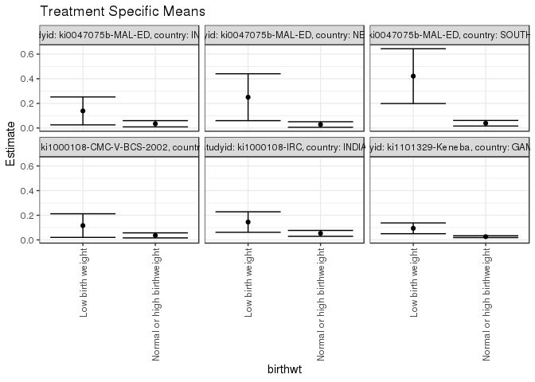

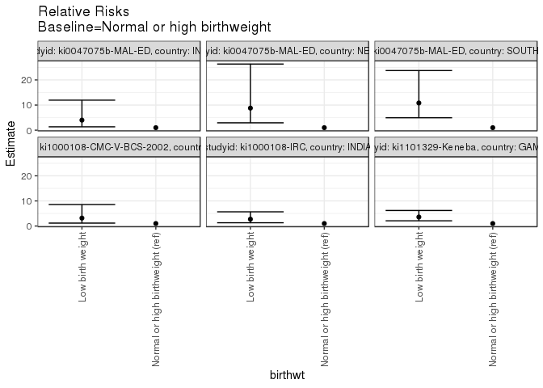

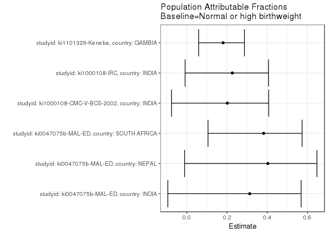

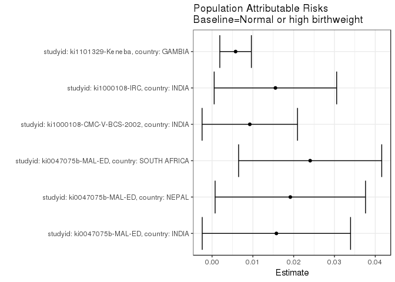

## Results Table

### Parameter: TSM

| studyid | country | intervention_level | baseline_level | estimate | ci_lower | ci_upper |
| --- | --- | --- | --- | --- | --- | --- |
| ki0047075b-MAL-ED | INDIA | Normal or high birthweight | NA | 0.0346535 | 0.0093779 | 0.0599291 |
| ki0047075b-MAL-ED | INDIA | Low birth weight | NA | 0.1388889 | 0.0256816 | 0.2520962 |
| ki0047075b-MAL-ED | NEPAL | Normal or high birthweight | NA | 0.0284360 | 0.0059600 | 0.0509120 |
| ki0047075b-MAL-ED | NEPAL | Low birth weight | NA | 0.2500000 | 0.0598152 | 0.4401848 |
| ki0047075b-MAL-ED | SOUTH AFRICA | Normal or high birthweight | NA | 0.0388693 | 0.0163129 | 0.0614256 |
| ki0047075b-MAL-ED | SOUTH AFRICA | Low birth weight | NA | 0.4210526 | 0.1986811 | 0.6434242 |
| ki1000108-CMC-V-BCS-2002 | INDIA | Normal or high birthweight | NA | 0.0366972 | 0.0162911 | 0.0571033 |
| ki1000108-CMC-V-BCS-2002 | INDIA | Low birth weight | NA | 0.1162791 | 0.0203368 | 0.2122213 |
| ki1000108-IRC | INDIA | Normal or high birthweight | NA | 0.0530973 | 0.0291989 | 0.0769958 |
| ki1000108-IRC | INDIA | Low birth weight | NA | 0.1449275 | 0.0617639 | 0.2280911 |
| ki1101329-Keneba | GAMBIA | Normal or high birthweight | NA | 0.0261866 | 0.0188743 | 0.0334989 |
| ki1101329-Keneba | GAMBIA | Low birth weight | NA | 0.0941176 | 0.0502137 | 0.1380216 |

### Parameter: E(Y)

| studyid | country | intervention_level | baseline_level | estimate | ci_lower | ci_upper |
| --- | --- | --- | --- | --- | --- | --- |
| ki0047075b-MAL-ED | INDIA | NA | NA | 0.0504202 | 0.0225627 | 0.0782776 |
| ki0047075b-MAL-ED | NEPAL | NA | NA | 0.0476190 | 0.0200971 | 0.0751410 |
| ki0047075b-MAL-ED | SOUTH AFRICA | NA | NA | 0.0629139 | 0.0354838 | 0.0903440 |
| ki1000108-CMC-V-BCS-2002 | INDIA | NA | NA | 0.0459459 | 0.0245838 | 0.0673081 |
| ki1000108-IRC | INDIA | NA | NA | 0.0686275 | 0.0440656 | 0.0931893 |
| ki1101329-Keneba | GAMBIA | NA | NA | 0.0319521 | 0.0242481 | 0.0396560 |

### Parameter: RR

| studyid | country | intervention_level | baseline_level | estimate | ci_lower | ci_upper |
| --- | --- | --- | --- | --- | --- | --- |
| ki0047075b-MAL-ED | INDIA | Normal or high birthweight | Normal or high birthweight | 1.000000 | 1.000000 | 1.000000 |
| ki0047075b-MAL-ED | INDIA | Low birth weight | Normal or high birthweight | 4.007936 | 1.342438 | 11.965953 |
| ki0047075b-MAL-ED | NEPAL | Normal or high birthweight | Normal or high birthweight | 1.000000 | 1.000000 | 1.000000 |
| ki0047075b-MAL-ED | NEPAL | Low birth weight | Normal or high birthweight | 8.791667 | 2.935208 | 26.333192 |
| ki0047075b-MAL-ED | SOUTH AFRICA | Normal or high birthweight | Normal or high birthweight | 1.000000 | 1.000000 | 1.000000 |
| ki0047075b-MAL-ED | SOUTH AFRICA | Low birth weight | Normal or high birthweight | 10.832536 | 4.942622 | 23.741211 |
| ki1000108-CMC-V-BCS-2002 | INDIA | Normal or high birthweight | Normal or high birthweight | 1.000000 | 1.000000 | 1.000000 |
| ki1000108-CMC-V-BCS-2002 | INDIA | Low birth weight | Normal or high birthweight | 3.168605 | 1.171519 | 8.570117 |
| ki1000108-IRC | INDIA | Normal or high birthweight | Normal or high birthweight | 1.000000 | 1.000000 | 1.000000 |
| ki1000108-IRC | INDIA | Low birth weight | Normal or high birthweight | 2.729469 | 1.316294 | 5.659828 |
| ki1101329-Keneba | GAMBIA | Normal or high birthweight | Normal or high birthweight | 1.000000 | 1.000000 | 1.000000 |
| ki1101329-Keneba | GAMBIA | Low birth weight | Normal or high birthweight | 3.594118 | 2.086794 | 6.190204 |

### Parameter: PAR

| studyid | country | intervention_level | baseline_level | estimate | ci_lower | ci_upper |
| --- | --- | --- | --- | --- | --- | --- |
| ki0047075b-MAL-ED | INDIA | Normal or high birthweight | NA | 0.0157667 | -0.0024116 | 0.0339450 |
| ki0047075b-MAL-ED | NEPAL | Normal or high birthweight | NA | 0.0191830 | 0.0007503 | 0.0376157 |
| ki0047075b-MAL-ED | SOUTH AFRICA | Normal or high birthweight | NA | 0.0240446 | 0.0065049 | 0.0415844 |
| ki1000108-CMC-V-BCS-2002 | INDIA | Normal or high birthweight | NA | 0.0092487 | -0.0024440 | 0.0209414 |
| ki1000108-IRC | INDIA | Normal or high birthweight | NA | 0.0155301 | 0.0005192 | 0.0305410 |
| ki1101329-Keneba | GAMBIA | Normal or high birthweight | NA | 0.0057655 | 0.0018980 | 0.0096330 |

### Parameter: PAF

| studyid | country | intervention_level | baseline_level | estimate | ci_lower | ci_upper |
| --- | --- | --- | --- | --- | --- | --- |
| ki0047075b-MAL-ED | INDIA | Normal or high birthweight | NA | 0.3127063 | -0.0946193 | 0.5684594 |
| ki0047075b-MAL-ED | NEPAL | Normal or high birthweight | NA | 0.4028436 | -0.0110249 | 0.6472928 |
| ki0047075b-MAL-ED | SOUTH AFRICA | Normal or high birthweight | NA | 0.3821834 | 0.1055436 | 0.5732633 |
| ki1000108-CMC-V-BCS-2002 | INDIA | Normal or high birthweight | NA | 0.2012952 | -0.0760648 | 0.4071646 |
| ki1000108-IRC | INDIA | Normal or high birthweight | NA | 0.2262958 | -0.0084487 | 0.4063970 |
| ki1101329-Keneba | GAMBIA | Normal or high birthweight | NA | 0.1804419 | 0.0588161 | 0.2863505 |